# Results section

Kaare

18/10/2022

# MATRINEM - Attempts at creating a NEC mouse model

## Methods and Materials

Prior to results are presented a short description of the studies conducted needs to be made.

Experiment no. 4 was the goal, but before we could test our overall hypothesis we needed to find out which combination of antibiotics and feeding scheme would results in the most NEC-like phenotype.

These research questions were investigated in 3 pre-experiments (PreExp 1-3), each with their own research questions.

### **Overview of all experiments**

PreExp 1

PreExp 2

PreExp 3

NEC-FvT

**Aim**

To test feasibility of formula feeding with PICC line

Selectively targeting gram positive vs. gram negative bacteria

Testing if there is an interaction-effect with feeding and antibiotics

Combining reults from PreExp 1-3 into final experimental setup.

Protocols

Testing a broad spectrum antibiotics mix in combination with formula feeding.

4 groups

1. CON-BF
2. CON-FF
3. AB-BF
4. AB-FF

Groups

Groups

Groups

N

38 (32 survived)

18

32

26

### PreExp 1 - Feasibility Study

#### **Rationale:**

*Chen et al.*, showed that Maternal Antibiotics Treatment (**MAT**) resulted in mild NEC-like symptoms of mice offspring. We believed that MAT combined with formula feeding (**FF**) of offspring would result in a worsened phenotype - even more NEC-like than either treatment on it’s own.

#### **Aim:**

To test if it was possible to keep mice separated from the mother alive from postnatal day 3 and 48 hours onwards.

#### **Research Questions:**

- Can we keep offspring alive with formula feeding?
- Will combining MAT with FF result in a more inflammatory intestine as measured by cytokine analysis in the ileum.

Experiment 1 was a pilot to test whether it was possible to feed 3-day old mice with the PICC. The experimental setup followed the standard setup. Antibiotics was administered according to the description in Chen et al., though with a lower dose based on previous experiments. Our primary study objective was survival. Secondary objective was macroscopic evaluation of intestines for inflammation, intestinal distention and similar NEC-like symptoms. One preliminary hypothesis was a reduction in weight of offspring from antibiotics-treated mothers.

**Results**:

38 mice were born to 6 different mothers. Of these 32 survived and were included in the analysis.

30 samples were available for analysis of concentrations of the proinflammatory cytokines INFg, IL-10, IL-12p70, IL-1b, IL-2, IL-4, IL-5, IL-6, KCGRO, TNFa. Concentrations were measured in 1-cm sections of proximal/distal ileum tissue using MSD Mesoscale Kits. Distributions were assessed for normality with Shapiro-Wilk Normality Test (see table below), and plot of data were made to assess distributions visually:

Normallity check of cytokine distribution (Shapiro-Wilk Normality Test, p < 0.05)

| cytokines | p |
| --- | --- |
| IL-10 | 0.0070630 |
| IL-12p70 | 0.9452073 |
| IL-1b | 0.0000002 |
| IL-2 | 0.0007820 |
| IL-4 | 0.0565021 |
| IL-5 | 0.5463809 |
| IL-6 | 0.0000502 |
| INFg | 0.0000000 |
| KCGRO | 0.0000019 |
| TNFa | 0.0000000 |

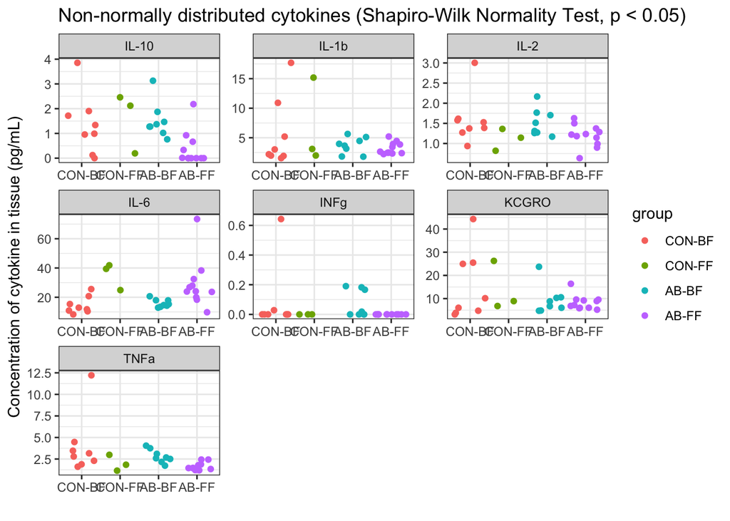

Non-normally distributed plots

The median concentration of the various cytokines are shown in the table below:

**Proinflammatory cytokines**

| Cytokines | Total number of mice analyzed = 30 **CON-BF**, N = 8<sup>1</sup> | Total number of mice analyzed = 30 **CON-FF**, N = 3<sup>1</sup> | Total number of mice analyzed = 30 **AB-BF**, N = 8<sup>1</sup> | Total number of mice analyzed = 30 **AB-FF**, N = 11<sup>1</sup> | **p-value**<sup>2</sup> |  |
| --- | --- | --- | --- | --- | --- | --- |
| IL-10 | 1.16 (0.7, 1.8) | 2.12 (1.2, 2.3) | 1.32 (1.2, 1.6) | 0.00 (0.0, 0.5) |  | 0.012 |
| IL-12p70 | 10.30 (7.4, 12.4) | 14.32 (14.1, 15.8) | 13.60 (10.4, 18.7) | 15.96 (9.4, 17.0) | 0.3 |  |
| IL-1b | 2.61 (2.0, 6.6) | 3.10 (2.5, 9.1) | 3.81 (2.8, 4.6) | 2.64 (2.4, 3.9) | >0.9 |  |
| IL-2 | 1.46 (1.3, 1.6) | 1.14 (1.0, 1.3) | 1.41 (1.3, 1.7) | 1.22 (1.1, 1.3) | 0.053 |  |
| IL-4 | 0.72 (0.6, 1.0) | 0.77 (0.7, 0.9) | 0.98 (0.9, 1.1) | 0.52 (0.5, 0.6) | 0.004 |  |
| IL-5 | 1.72 (1.6, 2.1) | 1.34 (1.2, 1.7) | 2.01 (1.5, 2.2) | 0.89 (0.6, 1.1) | <0.001 |  |
| IL-6 | 12.34 (10.8, 16.7) | 39.42 (32.2, 40.6) | 14.97 (14.1, 17.9) | 24.06 (21.8, 30.2) | 0.002 |  |
| KCGRO | 8.09 (4.5, 25.1) | 8.91 (7.9, 17.6) | 7.76 (5.7, 10.4) | 7.20 (6.0, 9.4) | 0.9 |  |
| TNFa | 2.98 (2.2, 3.7) | 1.84 (1.5, 2.4) | 2.64 (2.4, 3.3) | 1.45 (1.4, 1.8) | 0.004 |  |

* P-value indicates overall group differences  
**Matrinem round 1**  
<sup>1</sup> Median (IQR)  
<sup>2</sup> Kruskal-Wallis rank sum test

The cytokines that were significantly different between groups are shown below:

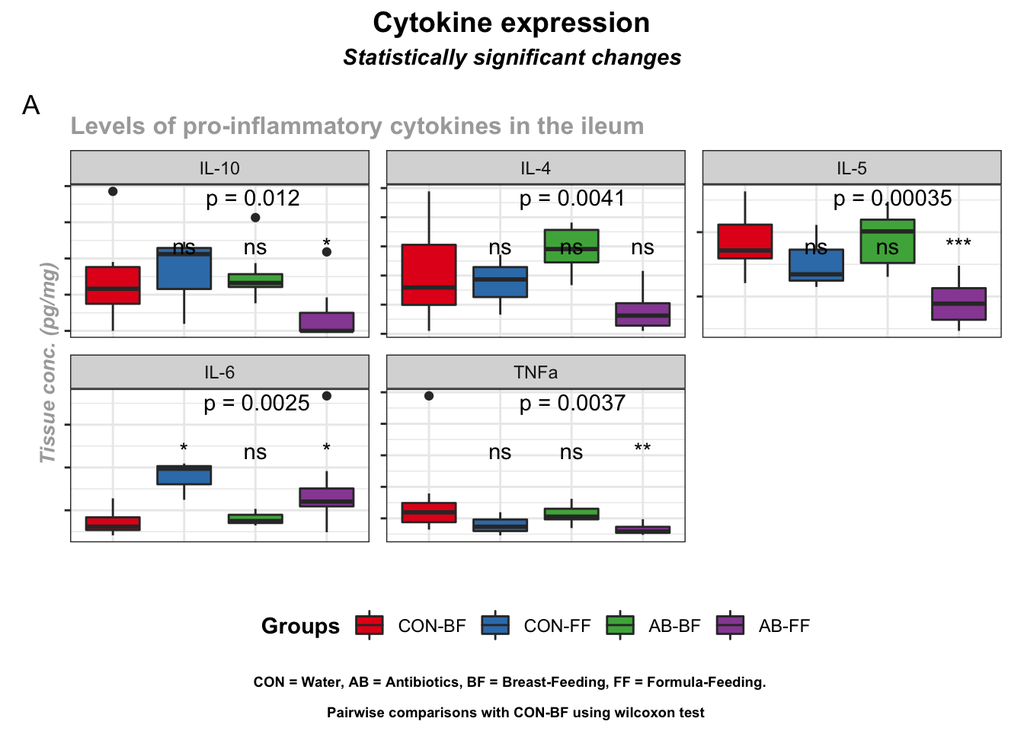

A linear regression analysis calculates the factors responsible for the changes observed.

Significant effectors on cytokine expression

| cytokines | term | estimate | std.error | p.value |
| --- | --- | --- | --- | --- |
| IL-10 | type_of_feedFF | -1.147 | 0.424 | 0.012 |
| IL-4 | type_of_feedFF | -0.433 | 0.099 | 0.000 |
| IL-4 | maternal_treatmentCON:type_of_feedFF | 0.361 | 0.176 | 0.050 |
| IL-5 | type_of_feedFF | -0.976 | 0.192 | 0.000 |
| IL-6 | type_of_feedFF | 13.091 | 5.143 | 0.017 |

#### Summary of PreExp 1

- Can we keep offspring alive with formula feeding?
  - After fine-tuning the feeding method we we able to successfully feed all surviving (32) mice every 3 hours.
  - The formulafed animals gained weight - albeit less than their breastfed peers - during the 48 hours.
  - MAT did not affect growth. CON-BF and AB-BF gained weight at a similar pace.

### PreExp 2 - Selectively targeting gram+ or gram- bacteria

- Will combining MAT with FF result in a more inflammatory intestine as measured by cytokine analysis in the ileum.